# Analiza Wypadków oraz Ruchu Granicznego w USA

### Cel Projektu

Celem projektu była analiza oraz wizualizacja danych dotyczących wypadków drogowych oraz ruchu granicznego na terytorium Stanów Zjednoczonych. Zrealizowaliśmy także aplikację Shiny, w której zaprezentowaliśmy nasze wykresy.

### Główne Wyniki

Wykonane przez nas wizualizacje pozwoliły zaobserwować szkodliwy wpływ alkoholu na bezpieczeństwo drogowe. Przeanalizowaliśmy również, jak w ciągu dnia zmienia się liczba wypadków w różnych godzinach. Na mapie przedstawiliśmy najpopularniejsze przejścia graniczne.

Projekt uważamy za udany, a wygląd aplikacji prezentuje się następująco:

### Wizualizacje

[figure not shown]

Widok aplikacji - 4

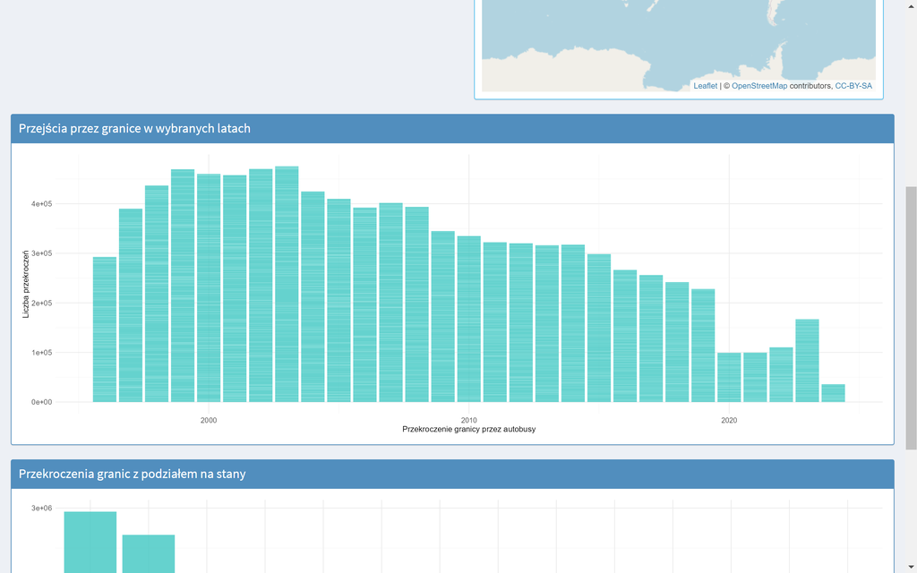

Widok aplikacji - 5

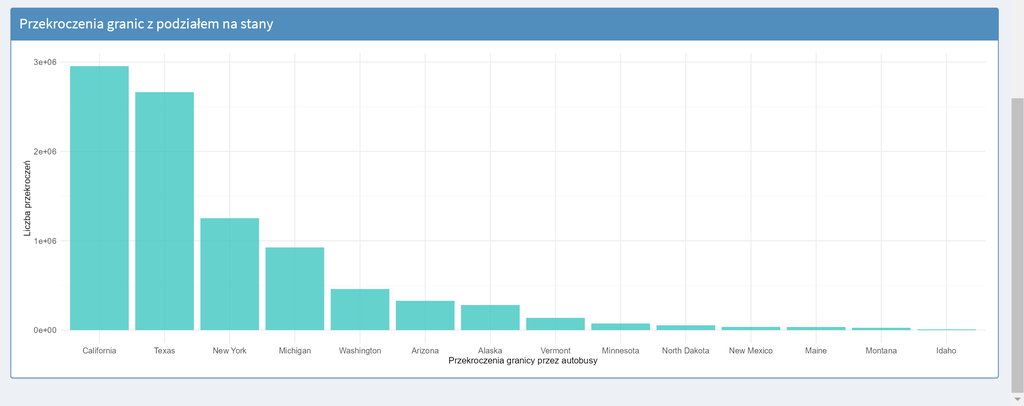

Widok aplikacji - 6

[figure not shown]

Widok aplikacji - 7

Przeanalizowaliśmy przepływ ruchu granicznego na terenie Stanów Zjednoczonych przy użyciu dwóch interaktywnych narzędzi wizualizacyjnych. Pierwsze z nich to mapa USA, na której zaznaczono miejsca przejść granicznych oraz przedstawiono intensywność ruchu przez każde z tych przejść. Drugim narzędziem jest histogram prezentujący przepływ ruchu przez granicę dla każdego stanu, umożliwiający analizę na podstawie różnych lat oraz środków transportu użytych do przekroczenia granicy.

Mapa USA z zaznaczonymi miejscami przejść granicznych dostarcza ogólnego przeglądu, gdzie koncentruje się ruch graniczny. Miejsca przejść granicznych są oznaczone według intensywności przepływu. Dane te można filtrować, aby zobaczyć, jak zmieniały się wzorce ruchu w różnych latach. Na przykład, w wybranych latach można zaobserwować wzrost ruchu w regionach południowych, co często związane jest z handlową wymianą z Meksykiem oraz migracją. W innych latach wzmożony ruch może występować na północnych przejściach, związany z ruchem towarowym i turystycznym z Kanady.

Histogram przedstawiający przepływ ruchu granicznego dla poszczególnych stanów USA daje szczegółowy wgląd w natężenie ruchu w poszczególnych rejonach kraju. Można zauważyć, że stany graniczące z Meksykiem, takie jak Teksas czy Kalifornia, mają tendencję do najwyższego poziomu ruchu granicznego, odzwierciedlając intensywną wymianę handlową oraz migrację. Stany na północy, jak Michigan czy Nowy Jork, również wykazują znaczny ruch, co jest związane z ich granicą z Kanadą i dużymi węzłami przemysłowymi.

Dzięki możliwości filtrowania danych histogramu według lat, można śledzić zmiany w przepływie ruchu granicznego w czasie. Na przykład, można zauważyć wzrost przepływu w czasie ekonomicznego wzrostu lub zmniejszenie podczas kryzysów gospodarczych.

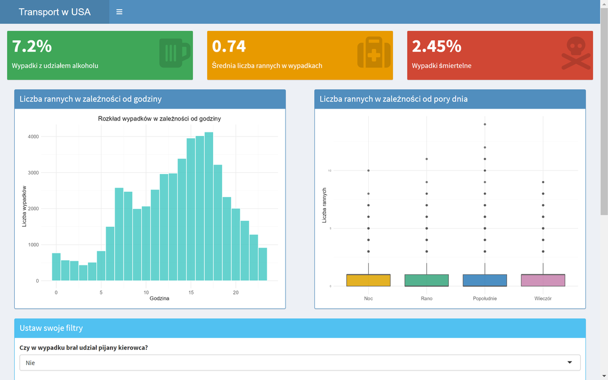

Widok aplikacji - 1

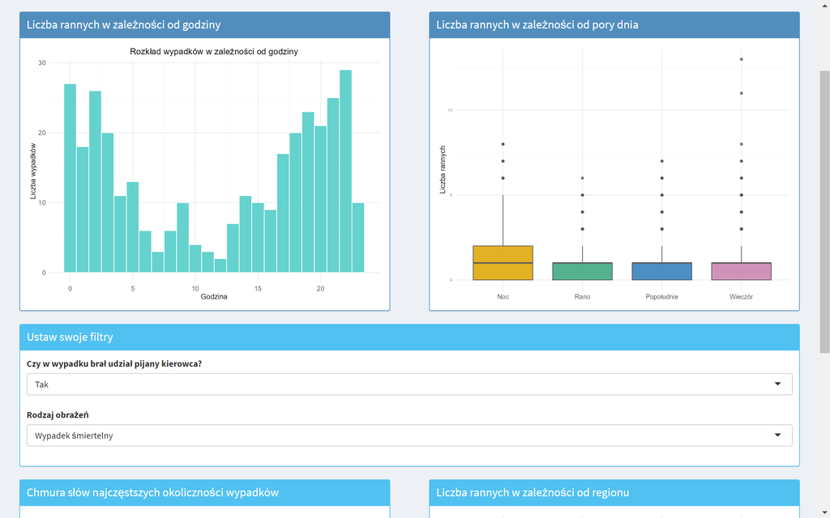

Widok aplikacji - 8

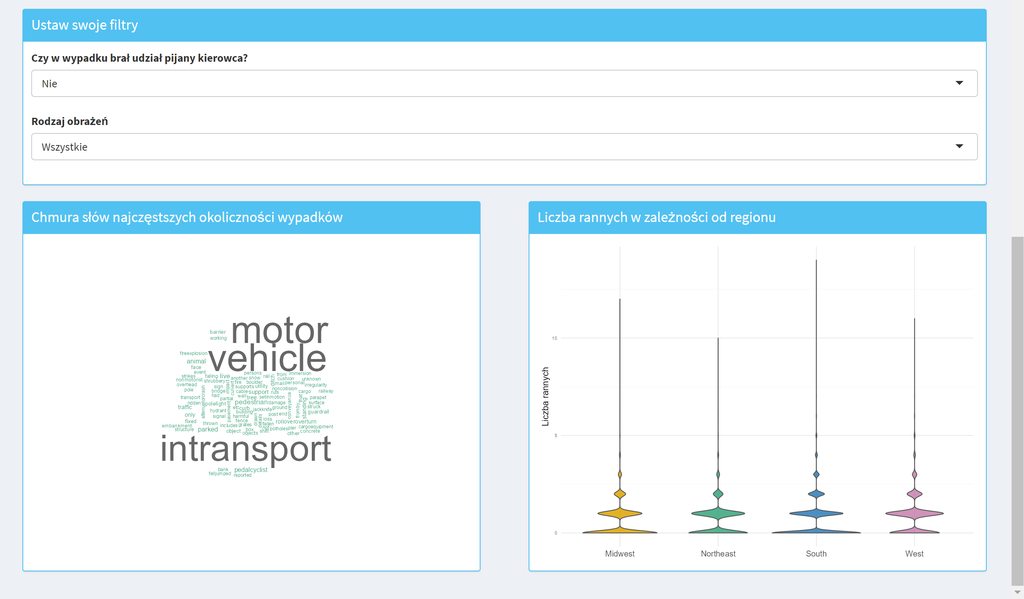

Widok aplikacji - 2

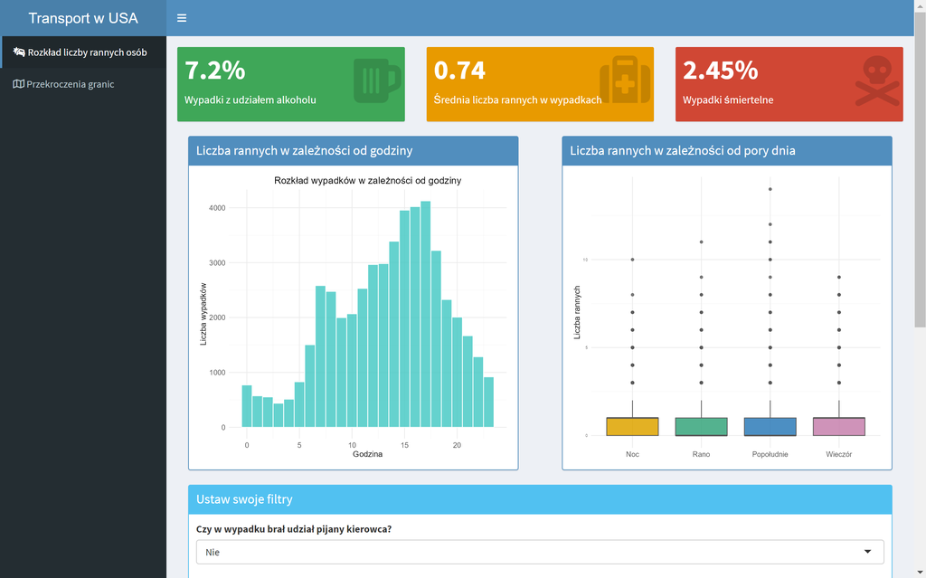

Widok aplikacji - 3

W tej części analizowaliśmy wpływ obecności pijanego kierowcy na rozkład godzinowy wypadków drogowych oraz na liczbę rannych w tych zdarzeniach. Badanie przeprowadzono przy użyciu interaktywnych wykresów, umożliwiających wyodrębnienie i porównanie wypadków z udziałem pijanego kierowcy oraz tych, w których pijany kierowca nie uczestniczył. Obserwacje zebrane z wykresów ujawniają istotne różnice w charakterystyce tych dwóch typów wypadków.

Wykres przedstawiający rozkład godzinowy wypadków drogowych wykazuje ogólne wzorce związane z ruchem drogowym. Wypadki są najczęstsze w godzinach porannych (7-9) oraz popołudniowych (16-18), co zazwyczaj koreluje z godzinami szczytu komunikacyjnego. Warto jednak zaznaczyć, że w godzinach popołudniowych wypadków jest więcej niż porannych, co może sugerować, że zmęczeni po pracy ludzie są mniej skupieni podczas jazdy niż kilka godzin wcześniej dopiero jadąc do niej.

Kiedy filtr zastosowano do wypadków z udziałem pijanego kierowcy, zauważalna jest ich koncentracja w godzinach wieczornych i nocnych, głównie między 20 a 4. To sugeruje, że obecność alkoholu w organizmie kierowców jest najczęstsza po wieczornych spotkaniach towarzyskich lub imprezach. W tym przedziale czasowym liczba wypadków z udziałem pijanego kierowcy znacznie wzrasta w porównaniu do ogólnego rozkładu.

Analiza liczby rannych w wypadkach również pokazuje interesujące różnice. Wypadki z udziałem pijanego kierowcy prowadzą do większej liczby rannych. Średnia liczba rannych w tych wypadkach jest znacząco wyższa w porównaniu do wypadków bez udziału pijanego kierowcy. To może sugerować, że alkohol wpływa negatywnie na zdolności kierowcy, zwiększając ryzyko poważniejszych obrażeń podczas wypadku.

Podsumowując, obecność pijanego kierowcy znacząco wpływa na rozkład wypadków drogowych i zwiększa liczbę rannych, co podkreśla potrzebę zintensyfikowania działań na rzecz poprawy bezpieczeństwa na drogach w kontekście przeciwdziałania prowadzeniu pojazdów pod wpływem alkoholu.